# Informe Uso del sistema Bicimad 2014-2018

## Introducción

La base de datos a trabajar corresponde a la información descargada via API de la página web del Datos abierto de Madrid: https://datos.madrid.es. El archivo contiene información en en formato **.csv** y registra la cantidad de veces por día que los **usuarios abonados anualmente y ocasionalmente** le dieron uso al sistema desde junio de 2014 hasta diciembre de 2018.

### Librerías a utilizar

Antes que nada procedemos a instalar las librerías que sabemos serán necesarias, en este caso

- library(lubridate)
- library(ggplot2)
- library(reshape2)

Son herramientas que en su orden nos ayudarán a ajustar datos con formato de fecha, a generar gráficas y a realizar modificaciones en las tablas y o datos.

```r
library(lubridate)
```

```r
library(ggplot2)
library(reshape2)
```

### Inspección de los datos

Con la primera inspeción entendemos que estamos tratando un dataframe de 8 columnas y 1653 observaciones. Además identificamos el tipo de dato: *integers* para las columnas númericas y *factor* para la columna fecha.

```r
biciusos <- read.table("../dat/bicis_usos_acumulado por dia.csv",sep=";",header = TRUE)
```

```r
 dim(biciusos)
```

```
## [1] 1653    8
```

```r
rbind(head(biciusos),tail(biciusos))
```

```
##             DIA Usos.bicis.abono.anual Usos.bicis.abono.ocasional
## 1    23/06/2014                     17                         79
## 2    24/06/2014                     24                         48
## 3    25/06/2014                    105                         14
## 4    26/06/2014                    120                         15
## 5    27/06/2014                    131                         18
## 6    28/06/2014                    101                         18
## 1648 26/12/2018                   6496                        124
## 1649 27/12/2018                   7282                        151
## 1650 28/12/2018                   7386                        256
## 1651 29/12/2018                   5584                        250
## 1652 30/12/2018                   5114                        301
## 1653 31/12/2018                   4718                        283
##      Usos.bicis.total Usos.abono.anual.acumulado
## 1                  96                         17
```

[output cut: 24 more lines]

```r
summary(biciusos)
```

```
##         DIA       Usos.bicis.abono.anual Usos.bicis.abono.ocasional
##  1/01/2015:   1   Min.   :   17          Min.   :  0.0
##  1/01/2016:   1   1st Qu.: 5413          1st Qu.: 61.0
##  1/01/2017:   1   Median : 8067          Median :148.0
##  1/01/2018:   1   Mean   : 8028          Mean   :169.9
##  1/02/2015:   1   3rd Qu.:10361          3rd Qu.:235.0
##  1/02/2016:   1   Max.   :16529          Max.   :745.0
##  (Other)  :1647
##  Usos.bicis.total Usos.abono.anual.acumulado
##  Min.   :   72    Min.   :      17
##  1st Qu.: 5525    1st Qu.: 2290500
##  Median : 8306    Median : 5991439
##  Mean   : 8198    Mean   : 5919122
##  3rd Qu.:10567    3rd Qu.: 9357290
##  Max.   :16732    Max.   :13271004
##
##  Usos.abono.ocasional.acumulado Usos.total.acumulado.desde.inicio
##  Min.   :    79                 Min.   :      96
##  1st Qu.: 46187                 1st Qu.: 2336687
##  Median :131358                 Median : 6122797
##  Mean   :126484                 Mean   : 6045606
##  3rd Qu.:208761                 3rd Qu.: 9566051
##  Max.   :280833                 Max.   :13551837
##
##     X
##  Mode:logical
##  NA's:1653
##
##
##
##
##
```

```r
 str(biciusos)
```

```
## 'data.frame':    1653 obs. of  8 variables:
##  $ DIA                              : Factor w/ 1653 levels "1/01/2015","1/01/2016",..: 831 886 941 996 1051 1106 1158 1263 25 619 ...
##  $ Usos.bicis.abono.anual           : int  17 24 105 120 131 101 107 121 124 128 ...
##  $ Usos.bicis.abono.ocasional       : int  79 48 14 15 18 18 33 16 6 2 ...
##  $ Usos.bicis.total                 : int  96 72 119 135 149 119 140 137 130 130 ...
##  $ Usos.abono.anual.acumulado       : int  17 41 146 266 397 498 605 726 850 978 ...
##  $ Usos.abono.ocasional.acumulado   : int  79 127 141 156 174 192 225 241 247 249 ...
##  $ Usos.total.acumulado.desde.inicio: int  96 168 287 422 571 690 830 967 1097 1227 ...
##  $ X                                : logi  NA NA NA NA NA NA ...
```

Teniendo en cuenta la información obtenida procedemos a eliminar la columna *‘X’* que a simple vista contiene datos *‘NA’* y sabemos que no aportará nada a nuestro tratamiento.

```r
biciusos$X<-NULL
```

Además vamos a generar una copia del fichero *(co.biciusos)* para trabajarlo libremente y realizar las modificaciones necesarias.

```r
co.biciusos<- biciusos
```

Para mejor manejo de las columnas vamos a reasignar nombres que sean mas digeribles para quién procesa los datos y para quién lee el informe.

```r
colnames(co.biciusos)<- c('fecha','abo_anual', 'abo_ocas','total_abo',
                         'usoanual_acum','usoocas_acum', 'usototal_acum')
```

Confirmamos la reasignación de nombres

```r
colnames(co.biciusos)
```

```
## [1] "fecha"         "abo_anual"     "abo_ocas"      "total_abo"
## [5] "usoanual_acum" "usoocas_acum"  "usototal_acum"
```

La columna **‘fecha’** se encuentra en formato **‘Factor’**, lo que nos dificulta su tratamiento, para esto vamos a generar una conversión a formato **‘caracter’** y luego a **‘date’**.

```r
 co.biciusos$fecha<-as.Date(as.character(dmy(co.biciusos$fecha)))
```

Con el fin de identificar más observaciones y obtener mas información sobre el comportamiento de los usuarios de Bicimad, vamos a extraer de la fecha, una columna con el año y otra con el mes.

```r
co.biciusos$ano<- year(co.biciusos$fecha)
co.biciusos$mes<- month(co.biciusos$fecha, label = TRUE)
co.biciusos$dia_semana<- wday(co.biciusos$fecha, label=TRUE)
```

Verificamos nuevamente el estado de la tabla *co.bicisusos* con sus columnas y nombres nuevos.

```r
head(co.biciusos)
```

```
##        fecha abo_anual abo_ocas total_abo usoanual_acum usoocas_acum
## 1 2014-06-23        17       79        96            17           79
## 2 2014-06-24        24       48        72            41          127
## 3 2014-06-25       105       14       119           146          141
## 4 2014-06-26       120       15       135           266          156
## 5 2014-06-27       131       18       149           397          174
## 6 2014-06-28       101       18       119           498          192
##   usototal_acum  ano    mes dia_semana
## 1            96 2014 Jun\\.     lun\\.
## 2           168 2014 Jun\\.     mar\\.
## 3           287 2014 Jun\\.     mié\\.
## 4           422 2014 Jun\\.     jue\\.
## 5           571 2014 Jun\\.     vie\\.
## 6           690 2014 Jun\\.     sáb\\.
```

Con las columnas nuevas ya determinadas, procedemos a eliminar columnas que no nos aportaban mayor análisis, en este caso columnas con datos acumulados que no interesan en este momento pero que visualmente sí molestan.

```r
co.biciusos$usoanual_acum<-co.biciusos$usoocas_acum<-co.biciusos$usototal_acum<-NULL
```

### GENERACIÓN Y ANÁLISIS DE GRÁFICAS

Consultamos nuevamente los datos para mayor claridad en la elaboración de las gráficas

```r
rbind(head(co.biciusos),tail(co.biciusos))
```

```
##           fecha abo_anual abo_ocas total_abo  ano    mes dia_semana
## 1    2014-06-23        17       79        96 2014 Jun\\.     lun\\.
## 2    2014-06-24        24       48        72 2014 Jun\\.     mar\\.
## 3    2014-06-25       105       14       119 2014 Jun\\.     mié\\.
## 4    2014-06-26       120       15       135 2014 Jun\\.     jue\\.
## 5    2014-06-27       131       18       149 2014 Jun\\.     vie\\.
## 6    2014-06-28       101       18       119 2014 Jun\\.     sáb\\.
## 1648 2018-12-26      6496      124      6620 2018 Dic\\.     mié\\.
## 1649 2018-12-27      7282      151      7433 2018 Dic\\.     jue\\.
## 1650 2018-12-28      7386      256      7642 2018 Dic\\.     vie\\.
## 1651 2018-12-29      5584      250      5834 2018 Dic\\.     sáb\\.
## 1652 2018-12-30      5114      301      5415 2018 Dic\\.     dom\\.
## 1653 2018-12-31      4718      283      5001 2018 Dic\\.     lun\\.
```

Con una gráfica **Boxplot** vamos a ver la *distribución de la demanda total por año*. Es decir, la demanda de los *dos tipos de usuarios*. Esto nos permite ver en términos generales como ha sido el comportamiento del sistema a lo largo de los 5 años (2014-2018).

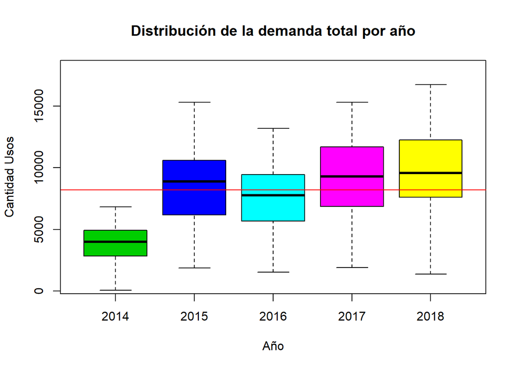

```r
boxplot(co.biciusos$total_abo~co.biciusos$ano , xlab = 'Año',
        ylab = 'Cantidad Usos', col = c(123,124,125,126,127), main='Distribución de la demanda total por año',
        ylim=c(500,18000) )
abline(h = mean(co.biciusos$total_abo), col = "red")
```

También aplicamos la misma técnica **Boxplot** para la distribución de la demanda ocasionada por el *Usuario de Abono ocasional*.

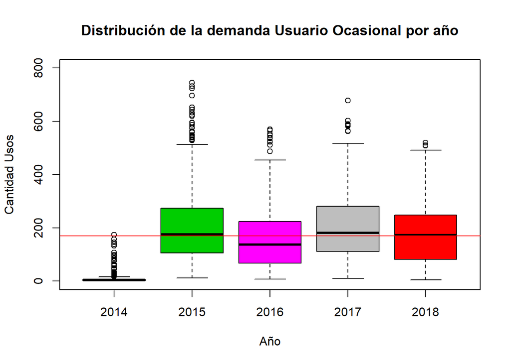

```r
boxplot(co.biciusos$abo_ocas~co.biciusos$ano , xlab = 'Año',
        ylab = 'Cantidad Usos', col = c(100,107,110,120,130), main='Distribución de la demanda Usuario Ocasional por año',
        ylim=c(0,800) )
abline(h = mean(co.biciusos$abo_ocas), col = "red")
```

Apreciamos como generando un **boxplot** por usuario nos permite ver las dimensiones o escalas que separan el comportamiento de cada *tipo de usuario*. Los *abonados ocasionales* generan un uso muy por debajo de los lo visto en la *Demanda total*, es decir el aporte de estos usuarios representa menos de un 5%.

Con el fin de exprimir un poco los datos vamos a aplicar una función **melt** para analizar otra perspectiva de los usos por usuario. Para esto crearemos una segunda tabla llamada **‘co.biciusosmelt’**.

```r
head(co.biciusosmelt<-melt(co.biciusos,id.vars = c('fecha','total_abo','ano',
  'mes','dia_semana' )))
```

```
##        fecha total_abo  ano    mes dia_semana  variable value
## 1 2014-06-23        96 2014 Jun\\.     lun\\. abo_anual    17
## 2 2014-06-24        72 2014 Jun\\.     mar\\. abo_anual    24
## 3 2014-06-25       119 2014 Jun\\.     mié\\. abo_anual   105
## 4 2014-06-26       135 2014 Jun\\.     jue\\. abo_anual   120
## 5 2014-06-27       149 2014 Jun\\.     vie\\. abo_anual   131
## 6 2014-06-28       119 2014 Jun\\.     sáb\\. abo_anual   101
```

Reasignamos nombre a la nueva columna generada por la función **Melt**.

```r
names(co.biciusosmelt)[6]<-'tipo_usuario'
```

La anterior conclusión lo podemos obvervar mas claramente en la siguiente tabla **tmp1**

```r
tmp1<-data.frame( rbind(tapply(co.biciusosmelt$value,co.biciusosmelt$tipo_usuario, sum)))
tmp1$total_usos<-tmp1$abo_ocas+tmp1$abo_anual
tmp1$peso_abo_ocas<-tmp1$abo_ocas/tmp1$total*100
tmp1$peso_abo_anual<-tmp1$abo_anual/tmp1$total*100
head(tmp1)
```

```
##   abo_anual abo_ocas total_usos peso_abo_ocas peso_abo_anual
## 1  13271004   280833   13551837      2.072287       97.92771
```

Para tener otra visión de la distribución analicemos cada *tipo de usuario* a lo largo de los años:

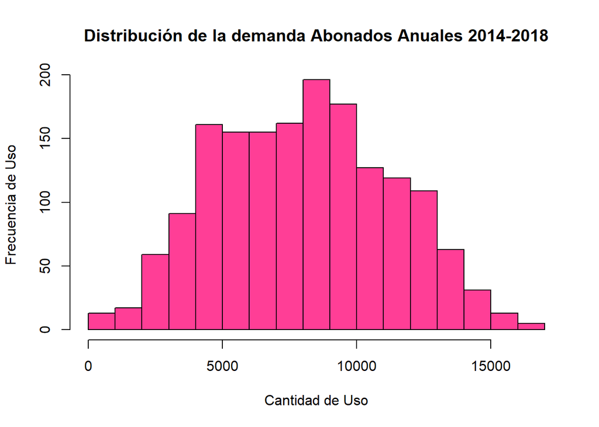

```r
hist(co.biciusos$abo_anual, main = "Distribución de la demanda Abonados Anuales 2014-2018",
     xlab = "Cantidad de Uso", ylab = "Frecuencia de Uso",
     col = "violetred1")
```

Observamos en este histograma una distribución normal con picos entre los 5.000 y 10.000 usos por mas de 150 veces.

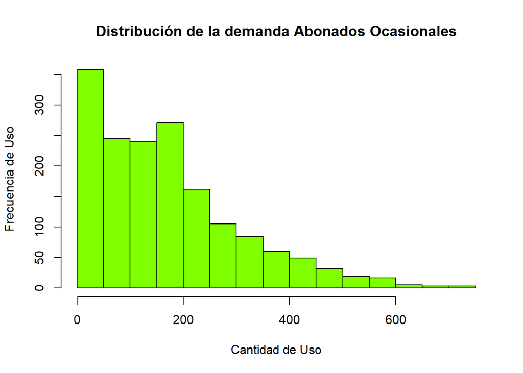

```r
hist(co.biciusos$abo_ocas, main = "Distribución de la demanda Abonados Ocasionales",
     xlab = "Cantidad de Uso", ylab = "Frecuencia de Uso",
     col = "chartreuse")
```

Otra forma de visualizar la diferencia en las escalas de los *usos por usuario* pero con las funciones **apply** y **melt** aplicada (Ya hablaremos de melt en siguiente paso).

```r
tmp<-tapply(co.biciusosmelt$value,co.biciusosmelt$tipo_usuario, mean)
tmp
```

```
## abo_anual  abo_ocas
## 8028.4356  169.8929
```

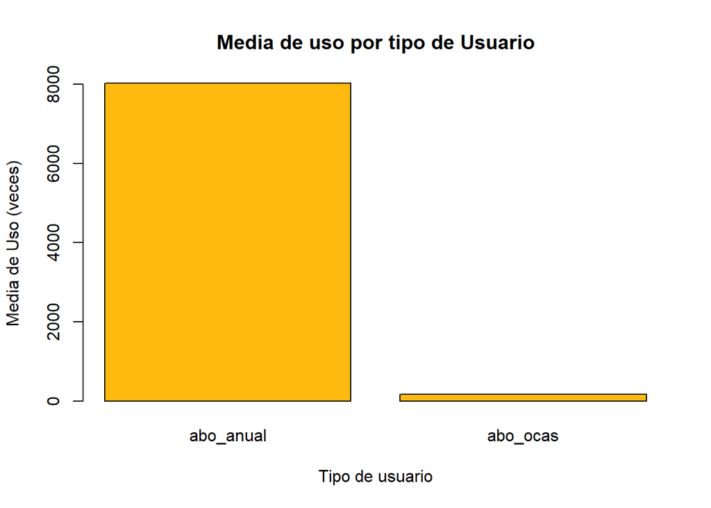

```r
barplot(tmp, main = "Media de uso por tipo de Usuario",
        ylab = "Media de Uso (veces)", xlab = "Tipo de usuario",
        col = "darkgoldenrod1")
```

Con la siguiente gráfica para poder ver la relación entre la demanda de **abonados anuales** y **abonados ocasionales**.

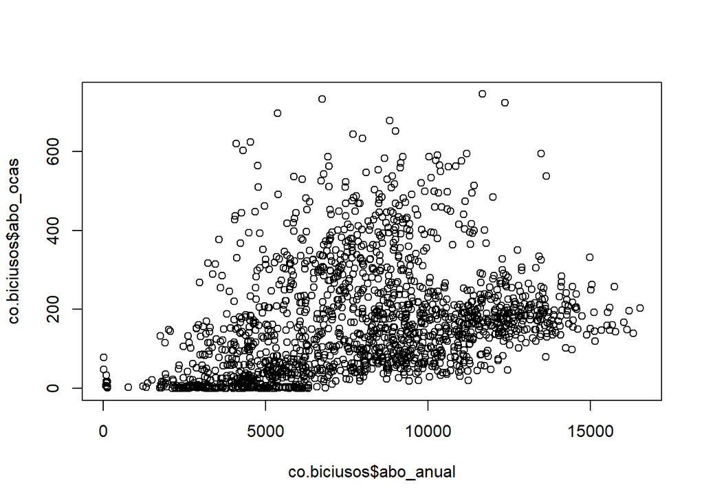

```r
plot(co.biciusos$abo_anual,co.biciusos$abo_ocas)
```

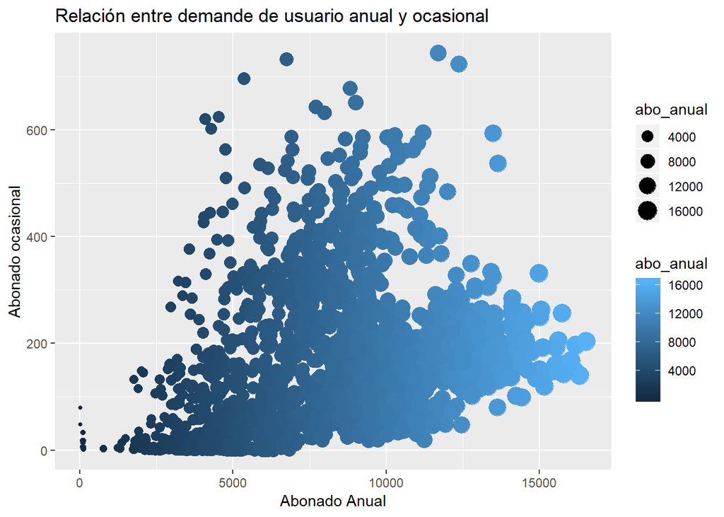

```r
g1 <- ggplot(co.biciusos, aes(x=abo_anual, y=abo_ocas))
g1 + geom_point(aes(size=abo_anual,color=abo_anual))+
  labs(title = 'Relación entre demande de usuario anual y ocasional', y='Abonado ocasional',
       x='Abonado Anual')
```

Aunque son demandas motivadas por necesidades distintas, sí podemos observar que tiene una relación en la medida que el aumento de una coincide con el aumento de la otra, aunque a diferentes escalas como lo hemos visto antes, pero si existe una tendencia clara entre ellas.

Grafica **ggplot** sobre el comportamiento de la demanda por día, por mes por tipo de usuario

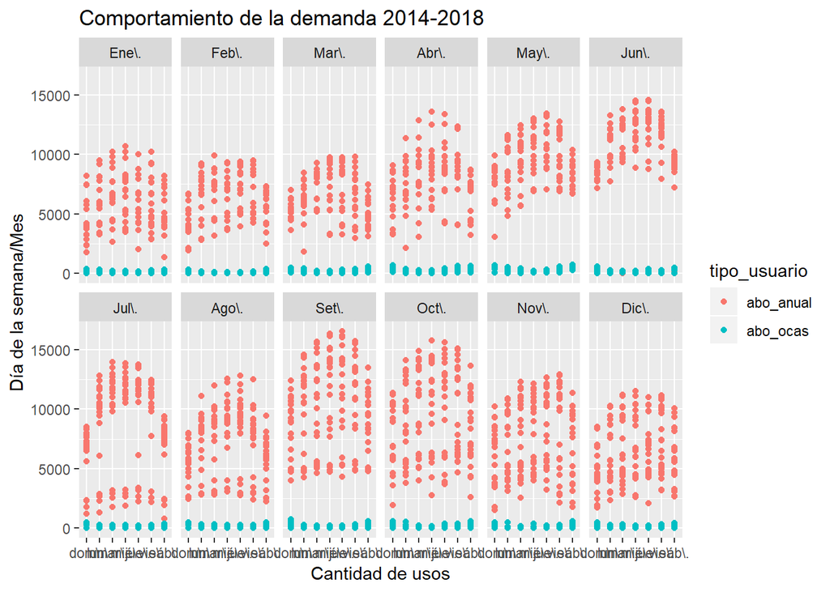

```r
gg1<-ggplot(co.biciusosmelt )+
  geom_point(aes(x=dia_semana, y= value, color= tipo_usuario))+
  geom_smooth(aes(x=dia_semana, y= value))
gg1 + facet_wrap(~mes,ncol = 6) +
  labs(title="Comportamiento de la demanda 2014-2018",
       x="Cantidad de usos", y="Día de la semana/Mes")
```

Gráfica **ggplot** de comportamiento mensual por año.

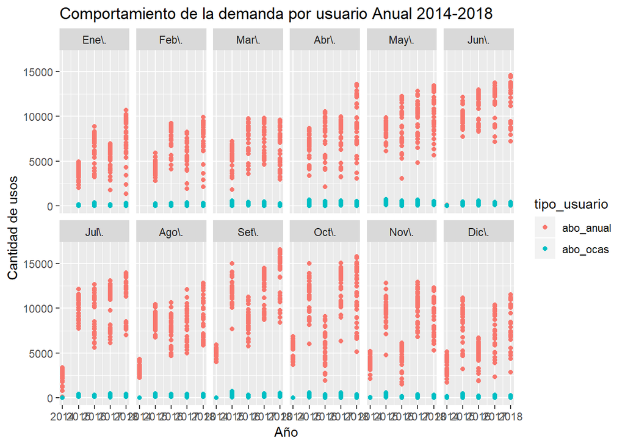

```r
gg2<-ggplot(co.biciusosmelt )+
  geom_point(aes(x=ano, y= value, color= tipo_usuario))
gg2 + facet_wrap(~mes,ncol = 6) +
  labs(title="Comportamiento de la demanda por usuario Anual 2014-2018",
       x="Año", y="Cantidad de usos")
```

Bicimad inicia labores en junio de 2014, razón por la que se puede observar en esta gráfica como los primeros meses de ese año no hay datos, y luego en el 6to mes aparece un subida abrupta. En esta otra gráfica tipo **ggplot de puntos** podemos observar como la tendencia ha venido a mas cada desde que inició el sistema, aunque en *2016* se presenta una caída en el mes de sepiembre, esto debido a la municipalización del sistema por el *Ayuntamiento de Madrid*, La adquisición se realizó en julio pero recién en agosto inició un plan de reparación total del las estaciones y bicicletas, dejando por fuera casi el 50% de las mismas, afectando su uso drásticamente. Este efecto se presenta en los *dos tipos de usuarios*, sin embargo, por obvias razones los **abonados anuales** que son los que mayor uso le dan al sistema, se vieron más afectados.

Con el fin de analizar variables adicionales que pueden afectar la demanda del sistema, vamos a cruzar la tabla de ‘co.bicisusos’ con una tabla con datos históricos del clima la cual contiene entre otas, la media del clima diario y si hubo precipitaciones o no, desde 2015.

Realizamos la importación de los datos los cuales están en formato .csv

```r
clima <- read.table("../dat/all_weather_data.csv",sep=",",header = TRUE)
```

Procedemos a la inspección de rutina de los datos

```r
dim(clima)
```

```
## [1] 1496   10
```

```r
rbind(head(clima),tail(clima))
```

```
##         X       date hour_temp_max hour_temp_min precipitation temp_max
## 1       0 2015-01-01      13:30:00      05:20:00           0.0     10.4
## 2       1 2015-01-02      15:10:00      07:20:00           0.0     12.0
## 3       2 2015-01-03      14:50:00      08:10:00           0.0     11.4
## 4       3 2015-01-04      13:15:00      08:10:00           0.0     14.0
## 5       4 2015-01-05      15:20:00      07:10:00           0.0     12.0
## 6       5 2015-01-06      15:10:00      07:40:00           0.0      9.8
## 1491 1490 2019-01-30      13:50:00      07:50:00           4.1     10.1
## 1492 1491 2019-01-31      13:20:00      00:00:00           8.2     12.4
## 1493 1492 2019-02-01      01:30:00      17:50:00           1.0      9.4
## 1494 1493 2019-02-02      13:25:00      21:30:00           0.0      7.5
## 1495 1494 2019-02-03      14:30:00      07:50:00           0.0      8.2
## 1496 1495 2019-02-04      15:55:00      07:20:00           0.0     10.9
##      temp_media temp_min wind_speed wind_speed_max
## 1           4.7     -1.0        0.8            3.9
## 2           5.5     -1.0        0.6            3.9
## 3           6.3      1.2        0.3            3.6
## 4           7.7      1.4        0.3            3.3
## 5           6.8      1.5        1.4            5.3
## 6           5.3      0.8        0.8            3.1
## 1491        7.2      4.2        3.3           10.8
## 1492        9.4      6.4        5.3           17.2
## 1493        6.4      3.5        3.9           16.1
## 1494        4.6      1.6        3.9           14.2
## 1495        4.0     -0.3        1.4           12.2
## 1496        4.8     -1.4        0.8            3.6
```

```r
summary(clima)
```

```
##        X                  date       hour_temp_max  hour_temp_min
##  Min.   :   0.0   2015-01-01:   1   14:30:00:102   00:00:00:115
##  1st Qu.: 373.8   2015-01-02:   1   00:00:00: 89   23:59:00:103
##  Median : 747.5   2015-01-03:   1   13:30:00: 89   06:10:00: 83
##  Mean   : 747.5   2015-01-04:   1   14:10:00: 87   06:30:00: 82
##  3rd Qu.:1121.2   2015-01-05:   1   15:10:00: 73   05:30:00: 77
##  Max.   :1495.0   2015-01-06:   1   14:40:00: 72   05:50:00: 77
##                   (Other)   :1490   (Other) :984   (Other) :959
##  precipitation       temp_max       temp_media       temp_min
##  Min.   : 0.000   Min.   : 0.00   Min.   : 0.00   Min.   :-3.00
##  1st Qu.: 0.000   1st Qu.:13.00   1st Qu.: 9.00   1st Qu.: 4.90
##  Median : 0.000   Median :19.80   Median :15.00   Median :10.20
##  Mean   : 1.102   Mean   :21.08   Mean   :15.98   Mean   :10.88
##  3rd Qu.: 0.000   3rd Qu.:28.93   3rd Qu.:22.80   3rd Qu.:16.80
##  Max.   :28.900   Max.   :40.00   Max.   :32.90   Max.   :25.90
##  NA's   :17
##    wind_speed   wind_speed_max
##  Min.   :0.00   Min.   : 0.00
##  1st Qu.:1.10   1st Qu.: 6.10
##  Median :1.70   Median : 8.60
##  Mean   :1.75   Mean   : 8.67
##  3rd Qu.:2.20   3rd Qu.:10.80
##  Max.   :6.40   Max.   :26.10
##
```

```r
str(clima)
```

```
## 'data.frame':    1496 obs. of  10 variables:
##  $ X             : int  0 1 2 3 4 5 6 7 8 9 ...
##  $ date          : Factor w/ 1496 levels "2015-01-01","2015-01-02",..: 1 2 3 4 5 6 7 8 9 10 ...
##  $ hour_temp_max : Factor w/ 89 levels "00:00:00","00:20:00",..: 41 60 55 38 62 60 55 57 64 55 ...
##  $ hour_temp_min : Factor w/ 115 levels "00:00:00","00:10:00",..: 45 68 77 77 66 71 77 46 43 75 ...
##  $ precipitation : num  0 0 0 0 0 0 0 0 0 0 ...
##  $ temp_max      : num  10.4 12 11.4 14 12 9.8 10.7 12.3 13.5 12.6 ...
##  $ temp_media    : num  4.7 5.5 6.3 7.7 6.8 5.3 5.8 6.4 7.8 7.2 ...
##  $ temp_min      : num  -1 -1 1.2 1.4 1.5 0.8 0.8 0.4 2 1.7 ...
##  $ wind_speed    : num  0.8 0.6 0.3 0.3 1.4 0.8 1.1 0.8 0.3 0.8 ...
##  $ wind_speed_max: num  3.9 3.9 3.6 3.3 5.3 3.1 4.4 5.3 4.2 3.3 ...
```

Como primera medida vamos a eliminar las columnas que no necesitamos y verificamos luego con Head()

```r
clima$X<-clima$hour_temp_max<-clima$hour_temp_min<-clima$temp_max<-clima$temp_min<-NULL
clima$wind_speed<-clima$wind_speed_max<-NULL
head(clima)
```

```
##         date precipitation temp_media
## 1 2015-01-01             0        4.7
## 2 2015-01-02             0        5.5
## 3 2015-01-03             0        6.3
## 4 2015-01-04             0        7.7
## 5 2015-01-05             0        6.8
## 6 2015-01-06             0        5.3
```

La idea es cruzar los datos de usos con la lluvia, columna ‘precipitation’ y la temperatura media, columna ‘temp_media, así podremos ver si existe relación entre estas dos variable y el uso del sistema. Para esto vamos a convertir la clase de dato de la columna ’fecha’ la cual viene en formato ‘factor’ a ‘Date’.

```r
clima$date<-as.Date(as.character(clima$date, 'y%/m%/%d'))

str(clima)
```

```
## 'data.frame':    1496 obs. of  3 variables:
##  $ date         : Date, format: "2015-01-01" "2015-01-02" ...
##  $ precipitation: num  0 0 0 0 0 0 0 0 0 0 ...
##  $ temp_media   : num  4.7 5.5 6.3 7.7 6.8 5.3 5.8 6.4 7.8 7.2 ...
```

El cruce de las dos trablas las haremos con la función MERGE. Crearemos una tabla nueva llamada ‘usoclima’ .En este caso son tablas donde la columna con la fecha tiene distintos nombres, además en la tabla ‘clima’ solo aparece información desde 2015, motivo por el cual especificaremos en la sentencia las columnas por el cual se hace el cruce, y desecharemos las fechas antes de 2015 en la tabla de ‘Usos’.

```r
usoclima<- merge(co.biciusos, clima, by.x = 'fecha', by.y = 'date')
usoclima2<- merge(co.biciusosmelt, clima, by.x = 'fecha', by.y = 'date')
```

Corroboramos la nueva tabla ‘usoclima’

```r
head(usoclima)
```

```
##        fecha abo_anual abo_ocas total_abo  ano    mes dia_semana
## 1 2015-01-01      2018      149      2167 2015 Ene\\.     jue\\.
## 2 2015-01-02      2880      153      3033 2015 Ene\\.     vie\\.
## 3 2015-01-03      3187      170      3357 2015 Ene\\.     sáb\\.
## 4 2015-01-04      3296      154      3450 2015 Ene\\.     dom\\.
## 5 2015-01-05      4039      117      4156 2015 Ene\\.     lun\\.
## 6 2015-01-06      2651      115      2766 2015 Ene\\.     mar\\.
##   precipitation temp_media
## 1             0        4.7
## 2             0        5.5
## 3             0        6.3
## 4             0        7.7
## 5             0        6.8
## 6             0        5.3
```

```r
head(usoclima2)
```

```
##        fecha total_abo  ano    mes dia_semana tipo_usuario value
## 1 2015-01-01      2167 2015 Ene\\.     jue\\.     abo_ocas   149
## 2 2015-01-01      2167 2015 Ene\\.     jue\\.    abo_anual  2018
## 3 2015-01-02      3033 2015 Ene\\.     vie\\.     abo_ocas   153
## 4 2015-01-02      3033 2015 Ene\\.     vie\\.    abo_anual  2880
## 5 2015-01-03      3357 2015 Ene\\.     sáb\\.     abo_ocas   170
## 6 2015-01-03      3357 2015 Ene\\.     sáb\\.    abo_anual  3187
##   precipitation temp_media
## 1             0        4.7
## 2             0        4.7
## 3             0        5.5
## 4             0        5.5
## 5             0        6.3
## 6             0        6.3
```

Ahora analicemos con una gráfica de puntos la relación del **Uso abonados anuales** con la **temperatura**

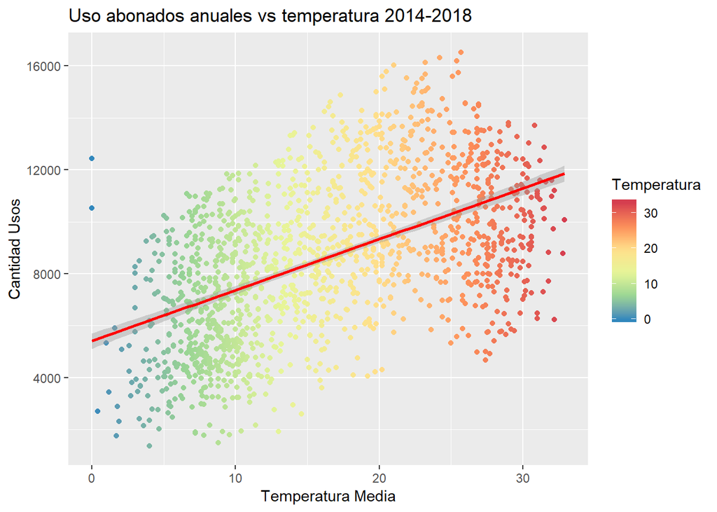

```r
gg3<-ggplot(usoclima, aes(x=temp_media, y=abo_anual, color=temp_media))+
  geom_point()+ scale_color_distiller("Temperatura", palette = "Spectral")+
  geom_smooth(method="lm", color='red')+
  labs(title="Uso abonados anuales vs temperatura 2014-2018",
       x="Temperatura Media", y="Cantidad Usos")
gg3
```

Relación del uso en abonados ocasionales con la temperatura

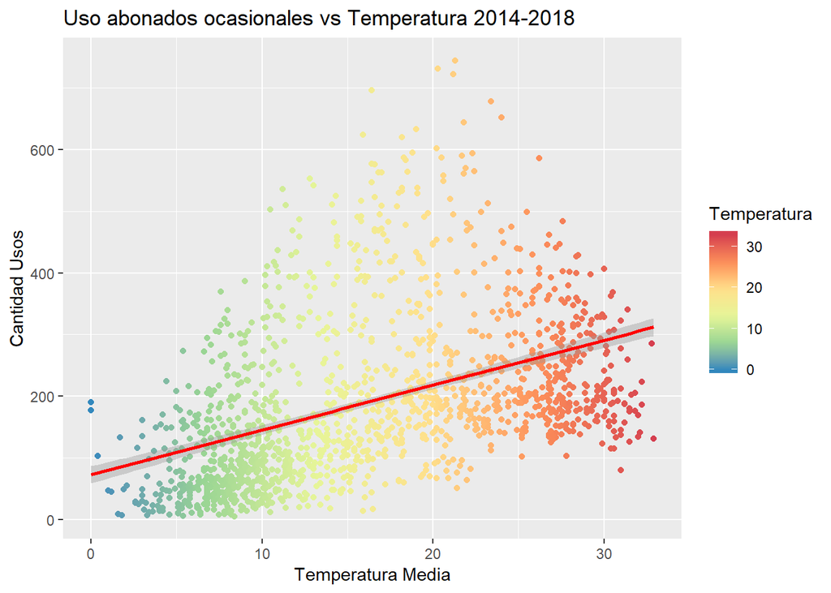

```r
gg4<-ggplot(usoclima, aes(x=temp_media, y=abo_ocas,color=temp_media))+
  geom_point()+scale_color_distiller("Temperatura", palette = "Spectral")+
geom_smooth(method="lm", color='red')+
  labs(title="Uso abonados ocasionales vs Temperatura 2014-2018",
       x="Temperatura Media", y="Cantidad Usos")
gg4
```

En las dos anteriores gráficas podemos observar como existe una relación directa entre la temperatura y el uso de las bicicletas. A medida que aumenta la temperatura aumenta el uso del sistema, sin embargo después de los 25 grados ya se empieza a notar un descenso en la cantidad de usos.

Relación entre la lluvia y el uso del sistema por usuarios

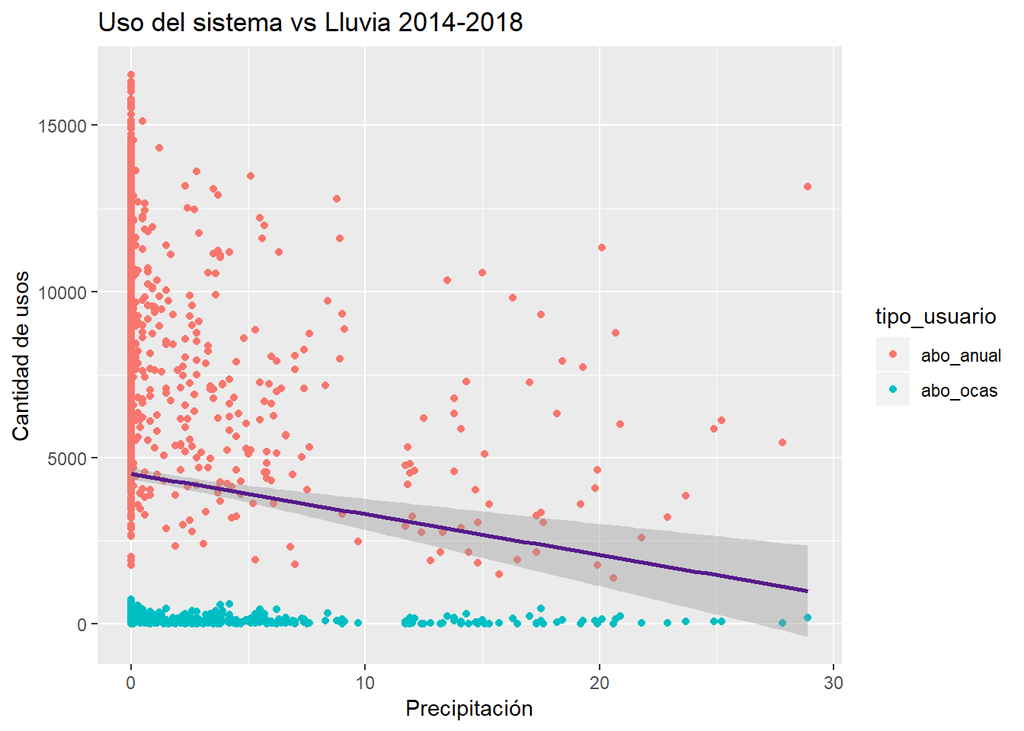

```r
gg5<-ggplot(usoclima2, aes(x=precipitation, y=value, color=tipo_usuario))+
  geom_point()+geom_smooth(method="lm", color= 'purple4')+
  labs(title="Uso del sistema vs Lluvia 2014-2018",
       x="Precipitación", y="Cantidad de usos")
gg5
```

Cuando llueve el sistema se usa pero en una mejor cantidad, evidentemente la mayor concentración de uso del sistema se da cuando las precipitaciones son cero (0).